# Workout 03

Akhil Perimbeti

12/8/2019

## 1) Extract Simple Information of the Authors

```r
# Paul Romer data

download.file('https://raw.githubusercontent.com/ucb-stat133/stat133-fall-2019/master/data/scholar/paul_romer_GoogleScholarCitations.html',destfile = "paul_romer_GoogleScholarCitations.webarchive")

rawdat1 =read_html('https://raw.githubusercontent.com/ucb-stat133/stat133-fall-2019/master/data/scholar/paul_romer_GoogleScholarCitations.html')

table1 <- html_table(rawdat1)

save(rawdat1, file = "/Users/akhilperimbeti/Desktop/workout03/data/rawdata/scholarA_GoogleScholarCitations.html")
# William Nordhaus data

download.file('https://raw.githubusercontent.com/ucb-stat133/stat133-fall-2019/master/data/scholar/william_nordhaus_GoogleScholarCitations.html',destfile = "william_nordhaus_GoogleScholarCitations.webarchive")

rawdat2 =read_html('https://raw.githubusercontent.com/ucb-stat133/stat133-fall-2019/master/data/scholar/william_nordhaus_GoogleScholarCitations.html')

table2 <- html_table(rawdat2)

save(rawdat2, file = "/Users/akhilperimbeti/Desktop/workout03/data/rawdata/scholarB_GoogleScholarCitations.html")
```

1. Extracting Scholar Names

```r
# Scholar A (Paul Romer)

name1 <- rawdat1 %>% html_nodes(xpath = '//*[@id="gsc_prf_in"]') %>% html_text
name1
```

```
## [1] "Paul Romer"
```

```r
# Scholar B (William Nordhaus)

name2 <- rawdat2 %>% html_nodes(xpath = '//*[@id="gsc_prf_in"]') %>% html_text
name2
```

```
## [1] "William Nordhaus"
```

2. Extracting Institutions affiliated with each scholar

```r
# Institution Affiliated with Scholar A

institution1 <- rawdat1 %>% html_nodes(xpath = '//*[@class="gsc_prf_il"]') %>% html_text
if (length(strsplit(institution1, ",")) == 0) {
  sa_institution = NA
} else {
  sa_institution = strsplit(institution1, ",")[[1]][2]
}
sa_institution
```

```
## [1] " New York University"
```

```r
# Institution Affiliated with Scholar B

institution2 <- rawdat2 %>% html_nodes(xpath = '//*[@class="gsc_prf_il"]') %>% html_text
if (length(strsplit(institution2, ",")) == 0) {
  sb_institution = NA
} else {
  sb_institution = strsplit(institution2, ",")[[1]][2]
}
sb_institution
```

```
## [1] NA
```

## 2) Extract All The Papers For Each Author (Not Just The 20 Most Cited)

```r
#CLEAN DATA

table_citations1=table1[[1]]
long_info1=table1[[2]][1]
citation1=table1[[2]][2]
year1=table1[[2]][3]


table_citations2=table2[[1]]
long_info2=table2[[2]][1]
citation2=table2[[2]][2]
year2=table2[[2]][3]

info_link1=rawdat1%>% html_nodes(xpath='//*[@id="gsc_a_b"]')%>%html_nodes(xpath='tr')%>%html_nodes(xpath='td')
result1=sapply(html_children(info_link1),html_text)
result1=result1[result1!='*']

info_link2=rawdat2%>% html_nodes(xpath='//*[@id="gsc_a_b"]')%>%html_nodes(xpath='tr')%>%html_nodes(xpath='td')
result2=sapply(html_children(info_link2),html_text)
result2=result2[result2!='*']


df1_citations=data.frame(article_title=result1[seq(1,length(result1),5)],

author=result1[seq(2,length(result1),5)],
                       journal=result1[seq(3,length(result1),5)],
                       citations=result1[seq(4,length(result1),5)],
                       year=result1[seq(5,length(result1),5)])


df2_citations =data.frame(article_title=result2[seq(1,length(result2),5)],
                       author=result2[seq(2,length(result2),5)],
                       journal=result2[seq(3,length(result2),5)],
                       citations=result2[seq(4,length(result2),5)],
                       year=result2[seq(5,length(result2),5)])

save(df1_citations, file= "/Users/akhilperimbeti/Desktop/workout03/data/cleandata/scholarA_GoogleScholarCitations.csv")
save(df2_citations, file= "/Users/akhilperimbeti/Desktop/workout03/data/cleandata/scholarB_GoogleScholarCitations.csv" )

final_df=rbind(df1_citations,df2_citations)

head(final_df, 5)
```

```
##                                              article_title
## 1                          Endogenous technological change
## 2                   Increasing returns and long-run growth
## 3                         The origins of endogenous growth
## 4               Economic integration and endogenous growth
## 5 Growth based on increasing returns due to specialization
##                      author
## 1                  PM Romer
## 2                  PM Romer
## 3                  PM Romer
## 4 LA Rivera-Batiz, PM Romer
## 5                  PM Romer
##                                                       journal citations
## 1 Journal of political Economy 98 (5, Part 2), S71-S102, 1990     29455
## 2        Journal of political economy 94 (5), 1002-1037, 1986     27658
## 3          Journal of Economic perspectives 8 (1), 3-22, 1994      4964
## 4   The Quarterly Journal of Economics 106 (2), 531-555, 1991      2698
## 5            The American Economic Review 77 (2), 56-62, 1987      2381
##   year
## 1 1990
## 2 1986
## 3 1994
## 4 1991
## 5 1987
```

```r
tail(final_df, 5)
```

```
##                                                 article_title
## 956                            Archive for the ‘WUWT’Category
## 957                                         of Climate Change
## 958                        Former title: Resources~ nd Energy
## 959 A Journal of Resource, Energy and Environmental Economics
## 960                               RESOURCE ANDENERGYECONOMICS
##                                                         author journal
## 956                                                WD Nordhaus
## 957                                                WD Nordhaus
## 958   CD KOLSTAD, MA ADELMAN, L BERGMAN, E BERNDT, G HEAL, ...
## 959  S SMULDERS, MA ADELMAN, L BERGMAN, P BOHM, F FØRSUND, ...
## 960 CD KOLSTAD, MA ADELMAN, L BERGMAN, E BERNDT, A FISHER, ...
##     citations year
## 956
## 957
## 958
## 959
## 960
```

## 3) Practice with Regular Expressions

(a) Paper titles that begin with a vowel

```r
# Paul Romer vowels
paul_vowels=0
for (i in 1:length(df1_citations[[1]])){
 if (substr(df1_citations[[1]][i],1,1)== "A" |substr(df1_citations[[1]][i],1,1)=="I" | substr(df1_citations[[1]][i],1,1)=="E"|substr(df1_citations[[1]][i],1,1)=="O"|substr(df1_citations[[1]][i],1,1)=="U"){paul_vowels = paul_vowels+1}
}

paul_vowels
```

```
## [1] 68
```

```r
# William Nordhaus vowels

william_vowels <- 0
for (i in 1:226) {
  if(any(substring(df2_citations[[1]][i], 1, 1) == c("A", "E", "I", "O", "U")) == TRUE) {
    william_vowels <- william_vowels + 1
  }
}
william_vowels
```

```
## [1] 76
```

2. Paper titles ending with “s”

```r
# "S" beginning papers for Paul Romer

paulpaper=0

for (i in 1:length(df1_citations[[1]])){
  a=nchar(substr(df1_citations[[1]][i],1,10000))
  if (substr(df1_citations[[1]][i],a,a)== "s"){paulpaper=paulpaper+1}
}
paulpaper
```

```
## [1] 41
```

```r
# "S" beginning paper for William Nordhaus

williampaper=0

for (i in 1:length(df2_citations[[1]])){
  a=nchar(substr(df2_citations[[1]][i],1,10000))
  if (substr(df2_citations[[1]][i],a,a)== "s"){williampaper=williampaper+1}
}
williampaper
```

```
## [1] 127
```

3. Longest Paper Titles for each author

```r
# Longest Title for Paul Romer
paultitle=0

for (i in 1:length(df1_citations[[1]])){
  x=nchar(substr(df1_citations[[1]][i],1,10000))
  if (x >paultitle){
    paultitle=x
    y=i}
}
paultitle
```

```
## [1] 179
```

```r
substr(df1_citations[[1]][y],1,100000000)
```

```
## [1] "What have we learned from a decade of empirical research on growth? Comment on ‘It's Not Factor Accumulation: Stylized Facts and Growth Models,’by William Easterly and Ross Levine"
```

```r
# Longest Title for William Nordhaus
willtitle=0

for (i in 1:length(df2_citations[[1]])){
  x=nchar(substr(df2_citations[[1]][i],1,10000))
  if (x > willtitle){
    willtitle= x
    y=i}
}

willtitle
```

```
## [1] 176
```

```r
substr(df2_citations[[1]][y],1,100000000)
```

```
## [1] "Cuốn kinh tế học của Paul A. Samuelson và William D. Nordhaus được xuất bản lần đầu vào năm 1948, đã được dịch ra nhiều thứ tiếng và tái bản tới 15 lần. Đồng thời được xem là …"
```

4. Variable number of punctuation symbols in titles. Summary stats and histograms

```r
# Paul Romer's symbols and histogram
paul_punctuation <- (str_count(df1_citations[[1]], "[:punct:]"))
summary(paul_punctuation)
```

```
##    Min. 1st Qu.  Median    Mean 3rd Qu.    Max.
##   0.000   0.000   1.000   1.381   2.000  13.000
```

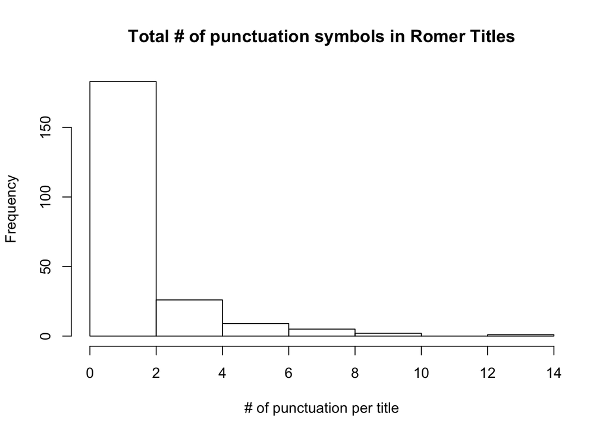

```r
hist(paul_punctuation, main = "Total # of punctuation symbols in Romer Titles", xlab = "# of punctuation per title")
```

```r
# William Nordhaus' symbols and histogram
william_punctuation <- (str_count(df2_citations[[1]], "[:punct:]"))
summary(william_punctuation)
```

```
##    Min. 1st Qu.  Median    Mean 3rd Qu.    Max.
##   0.000   0.000   1.000   1.292   2.000  31.000
```

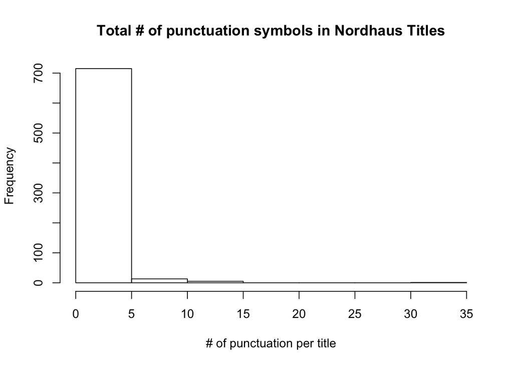

```r
hist(william_punctuation, main = "Total # of punctuation symbols in Nordhaus Titles", xlab = "# of punctuation per title")
```

5. Removing words –> the, a, an, and, in, if, but as well as numbers and punctuation from the titles.

```r
stop_words <- c("the", "a", "an", "and", "in", "if", "but", "of", "to", "from", "for", "on")

# Paul Romer titles without stop words, punctuation and numbers
low_df1 <- tolower(df1_citations[[1]])
p1 <- c()
s1<- c()

for (i in 1:226) {
  p1[i] <- removePunctuation(low_df1[i])
  p1[i] <- removeWords(p1[i], stop_words)
  p1[i] <- removeNumbers(p1[i])
  s1 <- c(s1, strsplit(p1[i], "\\s+")[[1]])
}
head(s1,20)
```

```
##  [1] "endogenous"    "technological" "change"        "increasing"
##  [5] "returns"       "longrun"       "growth"        ""
##  [9] "origins"       "endogenous"    "growth"        "economic"
## [13] "integration"   "endogenous"    "growth"        "growth"
## [17] "based"         "increasing"    "returns"       "due"
```

```r
# William Nordhaus titles without stop words, punctuation and numbers
low_df2 <- tolower(df2_citations[[1]])
p2 <- c()
s2<- c()

for (i in 1:226) {
  p2[i] <- removePunctuation(low_df2[i])
  p2[i] <- removeWords(p2[i], stop_words)
  p2[i] <- removeNumbers(p2[i])
  s2 <- c(s2, strsplit(p2[i], "\\s+")[[1]])
}
head(s2,20)
```

```
##  [1] ""          "political" "business"  "cycle"     "economie"
##  [6] ""          "review"    "stern"     "review"    "economics"
## [11] "climate"   "change"    ""          "question"  "balance"
## [16] "weighing"  "options"   "global"    "warming"   "policies"
```

6. Scholar A (Paul Romer) 10 most frequent words

```r
# Paul Rober's Top Ten Most Frequent Words
x=str_replace_all(df1_citations$article_title,"\\sthe\\s"," ")
words=table(tolower(unlist(strsplit(x,split=" "))))

words["and"]=0
words["the"]=0
words["of"]=0
words["in"]=0
words["from"]=0
words["an"]=0
words["a"]=0
words["to"]=0
words["for"]=0
words["on"]=0
head(sort(words,decreasing=TRUE),10)
```

```
##        growth      economic          with    endogenous    increasing
##            51            40            24            21            11
##       journal       returns technological   development           new
##            11            11            11            10            10
```

7. Scholar B (William Nordhaus) 10 most frequent words

```r
# William Norhaus' Top Ten Most Frequent Words
y=str_replace_all(df2_citations$article_title,"\\sthe\\s"," ")
words=table(tolower(unlist(strsplit(y,split=" "))))

words["and"]=0
words["the"]=0
words["of"]=0
words["in"]=0
words["from"]=0
words["an"]=0
words["a"]=0
words["to"]=0
words["for"]=0
words["on"]=0
head(sort(words,decreasing=TRUE),10)
```

```
##  economic   climate    global economics   warming    change    growth
##        87        73        72        54        49        48        34
##    policy    energy       new
##        34        28        28
```